# **CLASSIFICATION WITH TREE-BASED MODELS**

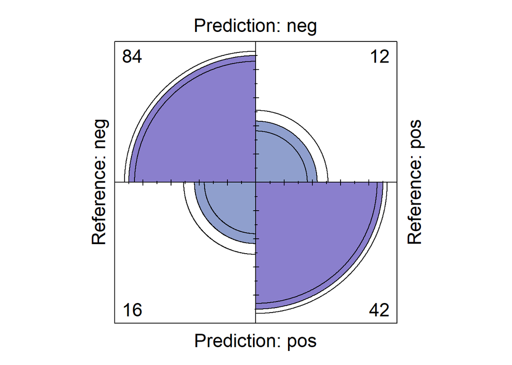

```r
balanced_forest_best_process <- select_best(balanced_tune_forest, metric = 'roc_auc')
balanced_best_forest <- finalize_model(balanced_forest, balanced_forest_best_process)
balanced_best_forest
Random Forest Model Specification (classification)

Main Arguments:
  mtry = 3
  trees = 500
  min_n = 27

Engine-Specific Arguments:
  num.threads = 8
  splitrule = gini
  importance = impurity_corrected

Computational engine: ranger

balanced_resamples_fit <- fit_resamples(balanced_best_forest, diabetes ~ .,
                               resamples = balanced_folds)
collect_metrics(balanced_resamples_fit)
# A tibble: 3 × 6
  .metric     .estimator  mean     n std_err .config
  <chr>       <chr>      <dbl> <int>   <dbl> <chr>
1 accuracy    binary     0.790     5 0.00903 Preprocessor1_Model1
2 brier_class binary     0.152     5 0.00592 Preprocessor1_Model1
3 roc_auc     binary     0.870     5 0.0126  Preprocessor1_Model1

balanced_forest_best_fit <- fit(balanced_best_forest, diabetes~., balanced_train)
balanced_forest_best_fit
parsnip model object

Ranger result

Call:
 ranger::ranger(x = maybe_data_frame(x), y = y, mtry = min_cols(~3,      x), num.trees = ~500, min.node.size = min_rows(~27L, x),      num.threads = ~8, splitrule = ~"gini", importance = ~"impurity_corrected",      verbose = FALSE, seed = sample.int(10^5, 1), probability = TRUE)

Type:                             Probability estimation
Number of trees:                  500
Sample size:                      811
Number of independent variables:  8
Mtry:                             3
Target node size:                 27
Variable importance mode:         impurity_corrected
Splitrule:                        gini
OOB prediction error (Brier s.):  0.151641

balanced_forest_pred.classes <- predict(balanced_forest_best_fit, test, type = "class")
balanced_forest_pred.classes <- factor(unlist(balanced_forest_pred.classes))
balanced_forest_confusion_matrix <- confusionMatrix(balanced_forest_pred.classes, test$diabetes,
                                        positive = "pos")
balanced_forest_confusion_matrix
Confusion Matrix and Statistics

          Reference
Prediction neg pos
       neg  84  12
       pos  16  42

               Accuracy : 0.8182
                 95% CI : (0.7481, 0.8757)
    No Information Rate : 0.6494
    P-Value [Acc > NIR] : 3.015e-06

                  Kappa : 0.6074

 Mcnemar's Test P-Value : 0.5708

            Sensitivity : 0.7778
            Specificity : 0.8400
         Pos Pred Value : 0.7241
         Neg Pred Value : 0.8750
             Prevalence : 0.3506
         Detection Rate : 0.2727
   Detection Prevalence : 0.3766
      Balanced Accuracy : 0.8089

       'Positive' Class : pos


fourfoldplot(balanced_forest_confusion_matrix$table, color = c("#8F9FCD", "#8A7FCD"))
```

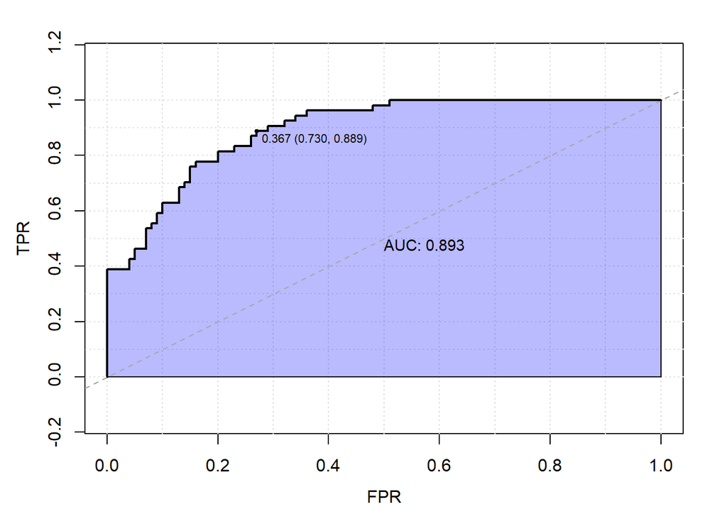

```r
balanced_forest_probabilities <- predict(balanced_forest_best_fit, test, type = "prob")
balanced_forest_curve <- roc(test$diabetes, balanced_forest_probabilities$.pred_pos)
plot.roc(balanced_forest_curve, print.auc = TRUE, auc.polygon = TRUE, asp = 0.50,
         grid = TRUE, identity.lty = 2, identity.lwd = 1, print.thres = TRUE,
         auc.polygon.col= rgb(0.1,0.1,1, alpha = 0.3), legacy.axes = TRUE,
         xlab = "FPR", ylab = "TPR", print.thres.cex = 0.7,
         print.auc.cex = 0.9)
```

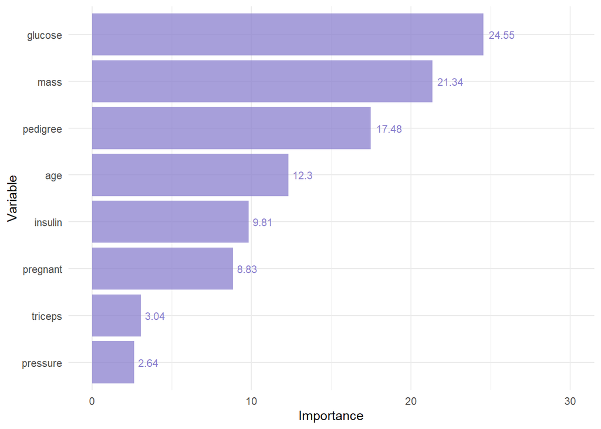

```r
balanced_forest_auc <- auc(balanced_forest_curve)
"forest_AUC" -> names(balanced_forest_auc)
balanced_forest_accuracy <- balanced_forest_confusion_matrix$overall['Accuracy']
balanced_forest_sensitivity <- balanced_forest_confusion_matrix$byClass['Sensitivity']
balanced_forest_specificity <- balanced_forest_confusion_matrix$byClass['Specificity']
balanced_forest_precision <- balanced_forest_confusion_matrix$byClass[5]
balanced_forest_performance_metrics <- c(balanced_forest_auc, balanced_forest_accuracy,
                                balanced_forest_sensitivity,
                                balanced_forest_specificity, balanced_forest_precision)

balanced_forest_performance_metrics
 forest_AUC    Accuracy Sensitivity Specificity   Precision
  0.8929630   0.8181818   0.7777778   0.8400000   0.7241379

balanced_forest_Var_Imp <- balanced_forest_best_fit$fit$variable.importance
balanced_forest_Var_Imp <- data.frame(balanced_forest_Var_Imp)
term <- rownames(balanced_forest_Var_Imp)
value <- balanced_forest_Var_Imp$balanced_forest_Var_Imp
balanced_forest_Var_Imp <- data.frame(term, value)

balanced_forest_Var_Imp$value <- (balanced_forest_Var_Imp$value/sum(balanced_forest_Var_Imp$value))*100

ggplot(balanced_forest_Var_Imp, aes(x = value, y =  reorder(term, value))) +
  geom_bar(stat = "identity", fill = "#8A7FCD", alpha = 0.75) +
  geom_text(aes(label = round(value, 2)), size = 3,
            hjust = -0.2, color = "#8A7FCD") +
  labs(x = "Importance", y = "Variable") +
  xlim(0,30) +
   theme_minimal()
```

### Gradient Boosted Trees

[Gradient Boosted Trees](https://www.machinelearningplus.com/machine-learning/an-introduction-to-gradient-boosting-decision-trees/) is a machine learning technique that creates a series of decision trees forming an ensemble. Each tree depends on the results of previous trees, and all trees produced through this process, are combined to produce a final prediction and create a ‘boosted’ version of predictive model. ‘GBT’ works by sequentially adding decision trees to the ensemble, with each tree aiming to correct the errors made by the previous ones. The sequential nature of GBT involves adding trees one at a time, with each subsequent tree aiming to improve upon the predictions of the previous trees in the series. This is done by focusing on the minimization of a loss function (such as mean squared error for regression or data-entropy for classification) using the [gradient descent algorithm](https://builtin.com/data-science/gradient-descent). Another way to put it and make it more concrete, is that every tree in the sequence is grown after the other and attempts to reduce the misclassification rate, meaning that the consequent tree is built upon the basis of giving higher weights to the misclassified points of its antecedents. While on the ensemble methods we saw earlier like bagged trees, and random forest, where each tree in the ensemble was built independently and then combined, in ‘GBT’ each tree derives as an improvement of its antecedents. In other words each tree tries to learn from the mistakes(prediction errors) made from the previous trees on the series. As for the data on which the algorithm is applied, the original dataset of predictors(no bootstrapping here), remains unchanged throughout the whole process while the column with the target variable is constantly being modified in a way to depict the errors made from the antecedent trees of the ensemble, and which aims to correct/minimize. You can choose to grow each tree in the series using the whole original data set, or a random sample of it. Exactly like in the case of a random forest, in the ‘GBT’ algorithm, you can random sample the number of predictors used for the grow of the tree, via the mtry parameter. In our presentation we use the [XGboost](https://xgboost.readthedocs.io/en/stable/), algorithm, and details about its parameterization via parnsip are here. One important thing to mention is that the time required to train a ‘GBT’ model and tune its parameters depends on several factors, including the size of the dataset, the complexity of the model, the number of hyperparameters being tuned, and the computational resources available(such as CPU speed, RAM and GPU availability). An attempt to tune all possible hyperparameters of the model, even in a small dataset can last ‘forever’, especially if you can’t enable gpu support for the XGBoost algorithm. You need to experiment, especially with the parameters of the gradient descent algorithm applied, to minimize the loss function.

Here are some general rules you can follow in order to build the model, while keeping a balance between computational costs, model performance and avoid a possible overfit of the model.  
- trees  
trees refer to the number of trees in the model. Increasing the value can improve the model performance, but can also lead to overfitting and increase training time  
- tree_depth  
The tree_depth parameter controls the maximum depth of the trees in the model. A larger max_depth value results in more complex models, which can lead to overfitting  
- min_n  
The minimum number of data points in a node that is required for the node to be split further. Smaller numbers of data points in a node, will lead to more complex trees and therefore, increase the risk of overfitting the model  
- mtry  
The number of predictors randomly sampled at each split when creating each tree. Like in the case of a random forest, constraining the number of predictors considered at each split, you can reduce the complexity of the trees and mitigate the effect of overfitting  
- loss_reduction  
The minimum value for the loss function to achieve, so as the tree will further grow with further splits. This parameter helps control the complexity of the tree by ensuring that splits are only made when they result in a sufficiently significant improvement in the model’s performance, therefore helping to prevent overfitting - learn_rate  
The step size taken at the gradient descent towards the local minimum(the min value for the loss function). Lower steps will lead to slower times for the algorithm to converge but also to a more accurate model  
- sample_size  
a proportion of random sample from the data, used per tree building iteration. This can improve the generalization fo the model, thus reduces the risk of a potential overfit and also reduces the time nedded for training the model  
- stop_iter  
The number of iterations without improvement before stopping. A bigger number will lead to more time needed for the algorithm to converge, and increase the chance of overfitting

- Original/Unbalanced approach

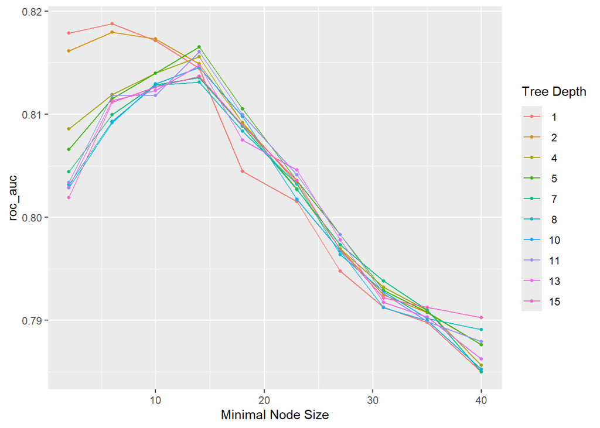

```r
library(xgboost)
set.seed(123)
boost_spec <- boost_tree(
                trees = 500,
                tree_depth = tune(),
                min_n = tune(),
                mtry = 3,
                loss_reduction = 2.25,
                learn_rate = 0.01,
                sample_size = 0.80,
                stop_iter = 3) %>%
                set_engine('xgboost', nthread = 8, importance = TRUE) %>%
                set_mode('classification')

boost_parameters <- extract_parameter_set_dials(boost_spec) %>%
                                  finalize(train)

boost_grid <- grid_regular(boost_parameters$object, levels = 10)

boost_recipe <- recipe(formula = diabetes ~ ., data = train)

boost_workflow <- workflow() %>%
                  add_recipe(boost_recipe) %>%
                  add_model(boost_spec)

tune_boost <- tune_grid(boost_workflow,
                         resamples = folds,
                         grid = boost_grid,
                         metrics = metric_set(roc_auc))

autoplot(tune_boost)
```

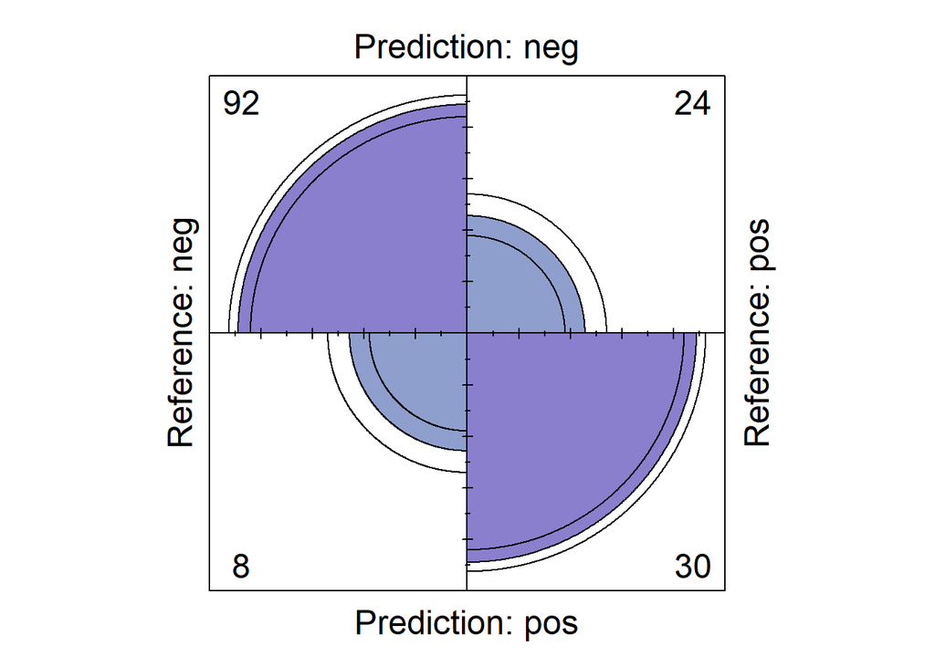

```r
boost_best_process <- select_best(tune_boost, metric = 'roc_auc')

best_boost <- finalize_model(boost_spec, boost_best_process)
best_boost
Boosted Tree Model Specification (classification)

Main Arguments:
  mtry = 3
  trees = 500
  min_n = 6
  tree_depth = 1
  learn_rate = 0.01
  loss_reduction = 2.25
  sample_size = 0.8
  stop_iter = 3

Engine-Specific Arguments:
  nthread = 8
  importance = TRUE

Computational engine: xgboost

resamples_fit <- fit_resamples(best_boost, diabetes ~ .,
                               resamples = folds)
collect_metrics(resamples_fit)
# A tibble: 3 × 6
  .metric     .estimator  mean     n std_err .config
  <chr>       <chr>      <dbl> <int>   <dbl> <chr>
1 accuracy    binary     0.756     5 0.0188  Preprocessor1_Model1
2 brier_class binary     0.165     5 0.00564 Preprocessor1_Model1
3 roc_auc     binary     0.817     5 0.0130  Preprocessor1_Model1

boost_best_fit <- fit(best_boost, diabetes~., train)
[10:15:39] WARNING: src/learner.cc:767:
Parameters: { "importance" } are not used.
boost_pred.classes <- predict(boost_best_fit, test, type = "class")
boost_pred.classes <- factor(unlist(boost_pred.classes))
boost_confusion_matrix <- confusionMatrix(data = boost_pred.classes,
                                        reference = test$diabetes, positive = "pos")
boost_confusion_matrix
Confusion Matrix and Statistics

          Reference
Prediction neg pos
       neg  92  24
       pos   8  30

               Accuracy : 0.7922
                 95% CI : (0.7195, 0.8533)
    No Information Rate : 0.6494
    P-Value [Acc > NIR] : 8.061e-05

                  Kappa : 0.5103

 Mcnemar's Test P-Value : 0.00801

            Sensitivity : 0.5556
            Specificity : 0.9200
         Pos Pred Value : 0.7895
         Neg Pred Value : 0.7931
             Prevalence : 0.3506
         Detection Rate : 0.1948
   Detection Prevalence : 0.2468
      Balanced Accuracy : 0.7378

       'Positive' Class : pos


fourfoldplot(boost_confusion_matrix$table, color = c("#8F9FCD", "#8A7FCD"))
```

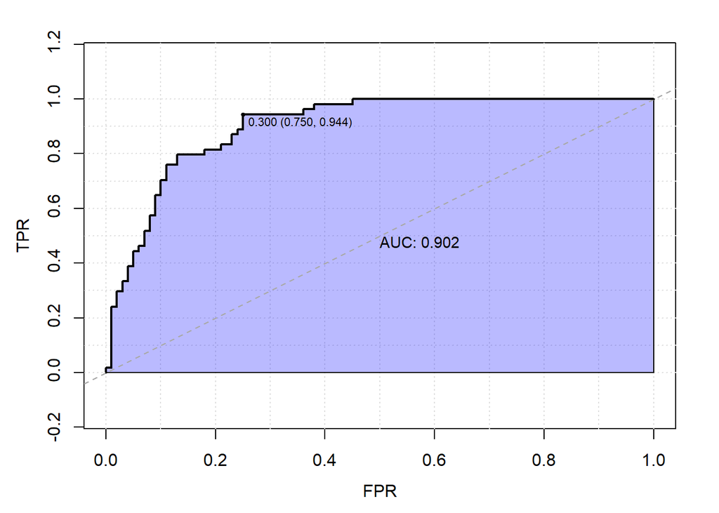

```r
boost_probabilities <- predict(boost_best_fit, test, type = "prob")
boost_curve <- roc(test$diabetes, boost_probabilities$.pred_pos)
plot.roc(boost_curve, print.auc = TRUE, auc.polygon = TRUE, asp = 0.50,
         grid = TRUE, identity.lty = 2, identity.lwd = 1, print.thres = TRUE,
         auc.polygon.col= rgb(0.1,0.1,1, alpha = 0.3), legacy.axes = TRUE,
         xlab = "FPR", ylab = "TPR", print.thres.cex = 0.7,
         print.auc.cex = 0.9)
```

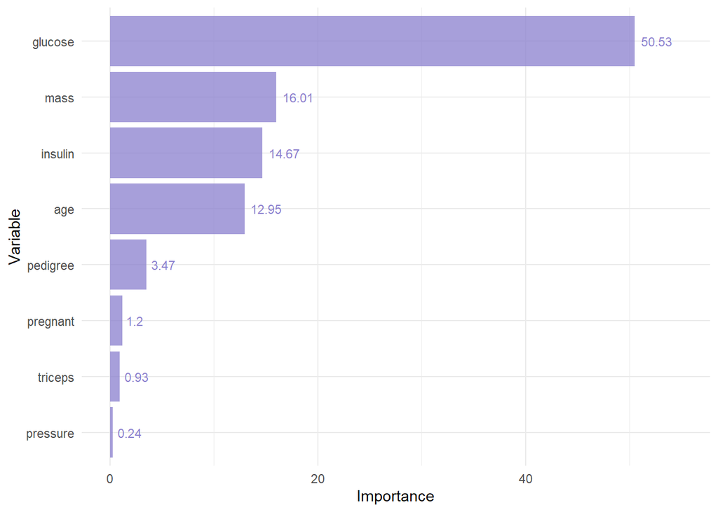

```r
boost_auc <- auc(boost_curve)
"boost_AUC" -> names(boost_auc)
boost_accuracy <- boost_confusion_matrix$overall['Accuracy']
boost_sensitivity <- boost_confusion_matrix$byClass['Sensitivity']
boost_specificity <- boost_confusion_matrix$byClass['Specificity']
boost_precision <- boost_confusion_matrix$byClass[5]
boost_performance_metrics <- c(boost_auc, boost_accuracy,
                                boost_sensitivity,
                                boost_specificity, boost_precision)

boost_performance_metrics
  boost_AUC    Accuracy Sensitivity Specificity   Precision
  0.9018519   0.7922078   0.5555556   0.9200000   0.7894737

boost_importance <- xgb.importance(boost_best_fit$fit$feature_names, boost_best_fit$fit)

boost_Var_Imp <- data.frame(boost_importance$Feature, boost_importance$Gain)

ggplot(boost_Var_Imp, aes(x = boost_importance$Gain*100,
                               y =  reorder(boost_importance$Feature,
                                            boost_importance$Gain))) +
  geom_bar(stat = "identity", fill = "#8A7FCD", alpha = 0.75) +
  geom_text(aes(label = round(boost_importance$Gain*100, 2)), size = 3,
            hjust = -0.2, color = "#8A7FCD") +
   labs(x = "Importance", y = "Variable") +
  xlim(0,55) +
   theme_minimal()
```

- Balanced/Oversampled approach

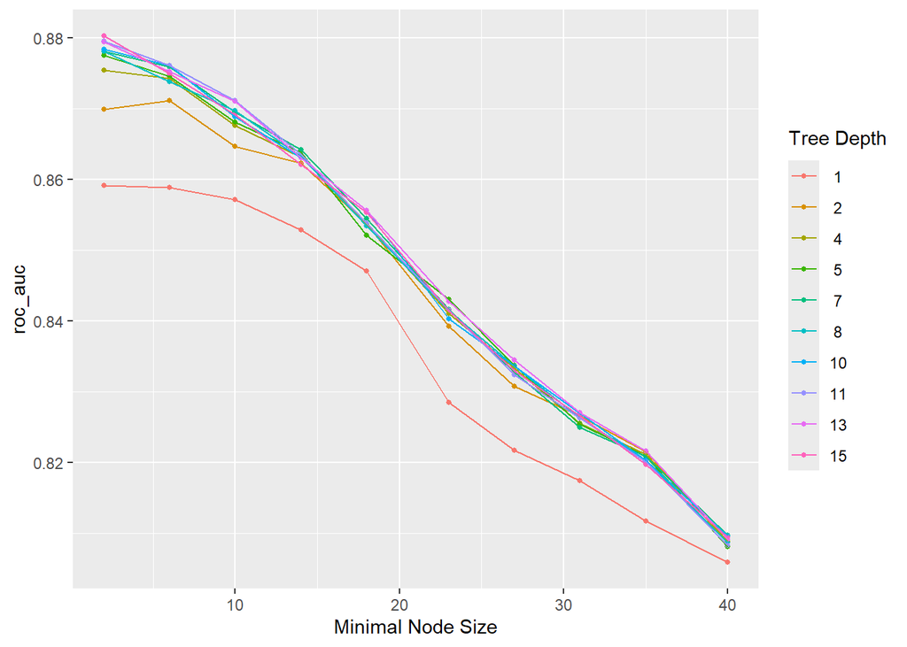

```r
library(xgboost)
set.seed(123)
balanced_boost_spec <- boost_tree(
                trees = 500,
                tree_depth = tune(),
                min_n = tune(),
                mtry = 3,
                loss_reduction = 2.25,
                learn_rate = 0.01,
                sample_size = 0.80,
                stop_iter = 3) %>%
                set_engine('xgboost', nthread = 8, importance = TRUE) %>%
                set_mode('classification')

balanced_boost_parameters <- extract_parameter_set_dials(balanced_boost_spec) %>%
                                  finalize(balanced_train)

balanced_boost_grid <- grid_regular(balanced_boost_parameters$object, levels = 10)

balanced_boost_recipe <- recipe(formula = diabetes ~ ., data = balanced_train)

balanced_boost_workflow <- workflow() %>%
                  add_recipe(balanced_boost_recipe) %>%
                  add_model(balanced_boost_spec)

balanced_tune_boost <- tune_grid(balanced_boost_workflow,
                         resamples = balanced_folds,
                         grid = balanced_boost_grid,
                         metrics = metric_set(roc_auc))

autoplot(balanced_tune_boost)
```